# Intervalos de confianza para regresión

Rodolfo Fernández de Lara Hadad -asistido por chatGPT y MS Copilot

2024-08-15

# Intervalos de Confianza y Predicción en Regresión Lineal

En regresión lineal, utilizamos intervalos de confianza y de predicción para evaluar la precisión de nuestras estimaciones y predicciones. Estos intervalos se calculan para:

1. **La media de la variable respuesta $y$**
2. **Un valor individual de la variable respuesta $y$**

## Intervalo de Confianza para la Media de $y$

Este intervalo proporciona un rango en el que esperamos que se encuentre la **media esperada** de $y$ para un conjunto específico de valores de las variables predictoras $X$.

La fórmula para calcular el intervalo de confianza para la media de $y$ es:

$$\hat{y}_0 \pm t_{\alpha/2} \cdot SE(\hat{y}_0)$$

Donde:

- $\hat{y}_0 = \hat{\beta}_0 + \hat{\beta}_1 X_1 + \dots + \hat{\beta}_p X_p$ es la estimación de la media de $y$.
- $t_{\alpha/2}$ es el valor crítico de la distribución $t$ de Student.
- $SE(\hat{y}_0) = \sqrt{\sigma^2 \left( 1/n + \frac{(X_0 - \bar{X})^2}{\sum_{i=1}^n (X_i - \bar{X})^2} \right)}$ es el error estándar de la estimación.

## Intervalo de Predicción para un Valor Individual de $y$

Este intervalo predice un **valor futuro individual** de $y$ dado un conjunto de valores de las variables predictoras $X$.

La fórmula para calcular el intervalo de predicción es:

$$\hat{y}_0 \pm t_{\alpha/2} \cdot SE_{pred}(\hat{y}_0)$$

Donde:

- $\hat{y}_0$ es la predicción del valor individual de $y$.
- $SE_{pred}(\hat{y}_0) = \sqrt{\sigma^2 \left( 1 + 1/n + \frac{(X_0 - \bar{X})^2}{\sum_{i=1}^n (X_i - \bar{X})^2} \right)}$ es el error estándar de la predicción.

## Implementación en R

A continuación, se muestra cómo calcular estos intervalos en R utilizando un ejemplo de regresión lineal y cómo generar una gráfica para visualizar las predicciones y sus intervalos:

```r
# Generar datos de ejemplo
set.seed(123)
x <- rnorm(100, mean = 5, sd = 2)
y <- 2 + 3 * x + rnorm(100)

# Ajustar el modelo de regresión lineal
modelo <- lm(y ~ x)

# Intervalos de confianza para los coeficientes
confint(modelo, level = 0.95)
```

```
##                2.5 %   97.5 %
## (Intercept) 1.446166 2.610586
## x           2.867716 3.079813
```

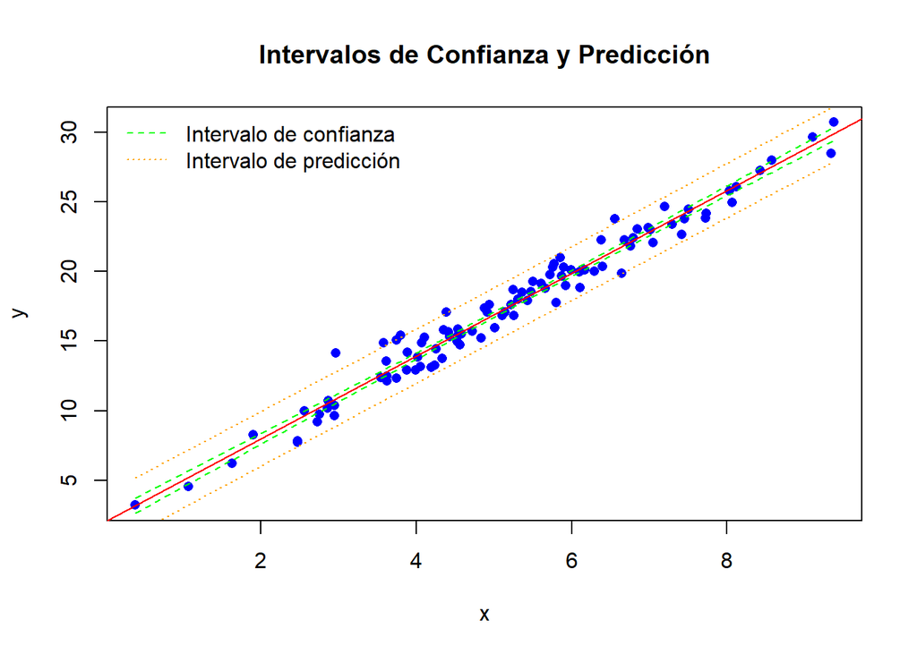

```r
# Nuevos datos para predicción
nuevos_datos <- data.frame(x = seq(min(x), max(x), length.out = 100))

# Intervalo de confianza para la media de y
pred_conf <- predict(modelo, nuevos_datos, interval = "confidence")

# Intervalo de predicción para valores individuales de y
pred_pred <- predict(modelo, nuevos_datos, interval = "prediction")

# Graficar
plot(x, y, main = "Intervalos de Confianza y Predicción",
     xlab = "x", ylab = "y", pch = 16, col = "blue")
abline(modelo, col = "red")

# Añadir el intervalo de confianza
lines(nuevos_datos$x, pred_conf[, "lwr"], col = "green", lty = 2)
lines(nuevos_datos$x, pred_conf[, "upr"], col = "green", lty = 2)

# Añadir el intervalo de predicción
lines(nuevos_datos$x, pred_pred[, "lwr"], col = "orange", lty = 3)
lines(nuevos_datos$x, pred_pred[, "upr"], col = "orange", lty = 3)

legend("topleft", legend = c("Intervalo de confianza", "Intervalo de predicción"),
       col = c("green", "orange"), lty = c(2, 3), bty = "n")
```